# STAT 413/613 Week 5: Open Data

Richard Ressler

2020-02-16

# 1 Learning Outcomes

- Identify potential sources for data from federal, state, local and international governments and agencies.

# 2 US Government Open Data Law

- On Jan 14, 2019, the [Foundations for Evidence-Based Policymaking Act of 2018](https://www.congress.gov/bill/115th-congress/house-bill/4174/text#toc-H8E449FBAEFA34E45A6F1F20EFB13ED95) became law.
- Known as the “Open Data Law”, it requires federal agencies to publish their information online as “open data”, using *standardized, machine-readable data formats*, with their metadata included in the Data.gov catalog.
- The [Federal Government Data Catalog](https://catalog.data.gov/dataset#topic=meta_navigation) has metadata on over 250,000 databases available for public use. Most are from state and local governments but there are many from the Federal level or international sources.

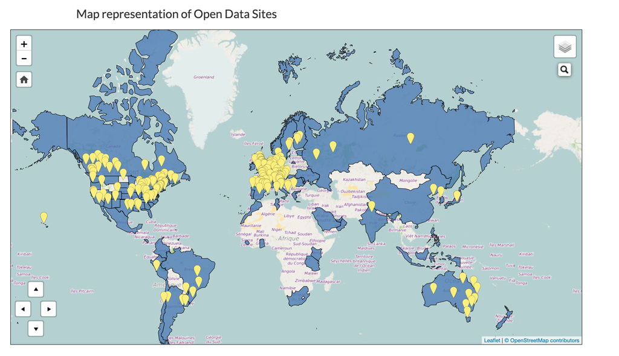

- The topics cover a wide range of government functions
- The data catalog has links to web sites or repositories from the sponsoring agency
  - In many cases, the data is not produced by the source but is curated by it as part of an international arrangement, e.g., meteorological or oceanic data

# 3 Federal Government Web Sites

- Most Departments Agencies, and offices of the federal government have their own websites for providing open data
- These websites often have tools for visualizing the data as well as downloads
- Downloads options can include multiple formats: e.g., zip, csv, html, or Excel as well as special formats for mapping data.
- Many sites allow for direct download via your browser while others may require FTP for large data sets.

## 3.1 Some Sites Are Modernized, Others are minimal

- [Census Bureau](https://data.census.gov/cedsci/) for data on US people and economy, as well as mapping data.
- [Department of Agriculture](https://www.usda.gov/content/usda-open-data-catalog)
- [Department of Commerce](https://data.commerce.gov/)
- [Department of Defense](https://data.defense.gov/Public-Data-Listing/Data-Listing-HTML/)
- [Department of Education](https://www2.ed.gov/about/data/list.html)
- [Department of Energy](https://www.energy.gov/data/downloads/open-data-catalogue) - A spreadsheet
- [Department of Health and Human Services](https://healthdata.gov/)
- [Department of Justice](https://www.justice.gov/open/inventory.php)
- [Department of Labor](https://catalog.data.gov/dataset?organization=dol-gov) links to the data.gov site with filters set to DOL
  - May be faster to go to the [Bureau of Labor Statistics](https://www.bls.gov/)
- [Department of State](https://catalog.data.gov/organization/state-gov)
- [Department of Transportation](https://catalog.data.gov/dataset/department-of-transportation-public-data-listing#__sid=md0) takes you to the data.gov catalog

# 4 Local Government Open Data Initiatives

Many locales have publicly-available data. A few examples

- [Baltimore](https://data.baltimorecity.gov/browse)
- [New Orleans](https://datadriven.nola.gov/inventory/)
- [New York City](https://opendata.cityofnewyork.us/data/)
- [San Francisco](https://datasf.org/opendata/)
- [Washington DC](https://opendata.dc.gov/)

# 5 Open Data exists in many countries.

- [United Nations](https://data.un.org/)
- [Open Data Portal Europe](https://www.europeandataportal.eu/)
- [OpenData](https://opendatabarometer.org/?_year=2017&indicator=ODB)

# 6 Bottom Line: Data, Data Everywhere / with Billions of Bytes to Think

*with apologies to Samuel Taylor Coleridge*  
- Don’t forget about other sources of “data”, e.g., [Library of Congress](https://www.loc.gov/) to help provide context for the nouns and numbers.